# All figures for normalization manuscript

Hanneke Leegwater

2024-03-15

This script reproduces all figures in the manuscript. The data directory needs to point to the correct location where the Calculations script has created files.

# Preparations

## Load R libraries

```r
library(tidyverse)
library(here)
```

```r
library(cowplot)
library(pheatmap)
library(ggvenn)
library(svglite)
source(here("code/functions/data_analysis_plots.R"))
```

## Define input and output directory

```r
data_dir <- here("manuscript/data_for_figures")
#data_dir <- here("data/normalization_manuscript_files")

output_dir <- here("manuscript", str_glue("figures_v{str_remove_all(Sys.Date(), '-')}"))
print(output_dir)
```

```
## [1] "C:/Users/leegwaterh/surfdrive/Manuscripts/2_the_lipidomics_normalization_story/code/manuscript/figures_v20240315"
```

```r
if(!dir.exists(output_dir)) dir.create(output_dir)
```

## Load all metadata

```r
# Sample metadata
metadata <- read_csv(here(data_dir, "metadata.csv"),
                    col_types = cols(batch_MSMS = col_factor(levels = c("1",
           "2", "3"))))

print(dim(metadata))
```

```
## [1] 213  13
```

```r
print(head(metadata))
```

```
## # A tibble: 6 × 13
##   Original_name group  cell_line Treatment  Time biological_replicate batch_MSMS
##   <chr>         <chr>  <chr>     <chr>     <dbl>                <dbl> <fct>
## 1 1_MDA-MB-231  MDA-M… MDA-MB-2… <NA>         NA                    1 2
## 2 2_Hs578T      Hs578T Hs578T    <NA>         NA                    1 2
## 3 3_T47D        T47D   T47D      <NA>         NA                    1 3
## 4 4_MCF-7       MCF-7  MCF-7     <NA>         NA                    1 3
## 5 5_SUM52PE     SUM52… SUM52PE   <NA>         NA                    1 3
## 6 6_HCC38       HCC38  HCC38     <NA>         NA                    1 3
## # ℹ 6 more variables: Study <chr>, cell_nr_10E6 <dbl>,
## #   corrected_conc_mg_per_mL <dbl>, Morphology <chr>, Cellosaurus_RRID <chr>,
## #   Cellosaurus_Cell_line_name <chr>
```

```r
### Information on lipid classes
lipid_info <- read_csv(here(data_dir, "lipid_info.csv"))
print(head(lipid_info))
```

```
## # A tibble: 6 × 11
##   internal_identifiers identifiers Abbreviation `Common Name`         RSD_QC
##   <chr>                <chr>       <chr>        <chr>                  <dbl>
## 1 ANG_SM_d32.2         SM d32:2    SM(d32:2)    Sphingomyelin (d32:2)  14.3
## 2 ANG_SM_d33.0         SM d33:0    SM(d33:0)    Sphingomyelin (d33:0)  12.8
## 3 ANG_SM_d33.1         SM d33:1    SM(d33:1)    Sphingomyelin (d33:1)  14.9
## 4 ANG_SM_d33.3         SM d33:3    SM(d33:3)    Sphingomyelin (d33:3)   9.09
## 5 ANG_SM_d34.0         SM d34:0    SM(d34:0)    Sphingomyelin (d34:0)  13.4
## 6 ANG_SM_d34.1         SM d34:1    SM(d34:1)    Sphingomyelin (d34:1)  12.5
## # ℹ 6 more variables: measurement_mode <chr>, quality <chr>,
## #   `Swiss Lipids` <chr>, ISTD <chr>, class <chr>, subclass <chr>
```

```r
print(dim(lipid_info))
```

```
## [1] 870  11
```

## Define all colors used in the manuscript

```r
color_legend_morphology <- list(
  "Epithelial-like" = "#FDE725FF", # scales::viridis_pal()(5)[5],
  "Mesenchymal-like" = "#3B528BFF", # scales::viridis_pal()(5)[1],
  "E" = "#FDE725FF",
  "M" = "#3B528BFF",
  "Round" = "#CB181D",
  "Suspension" = "#5DC863FF",
  "Unknown" = "grey"
)

color_legend_icc <- list(
  "data-based" = "#0099FF",
  "biology-based" = "#FF9B2D",
  "not normalized" = "grey"
)

color_legend_measurement_modes <- list(mode = c(
  "Positive" = "#F46E31",
  "Negative" = "#001158",
  "Switching" = "#A5B2E3"
))

color_legend_triglycerides <- list(
  "triglyceride" = "#001158",
  "other lipid class" = "#F46E31"
)
```

## Define personal theme to use for all plots

Adapted from tutorial: Harvard Chan Bioinformatics Core (HBC) with CC BY 4.0, https://hbctraining.github.io/publication_perfect/

```r
personal_theme <- function(){
  theme_half_open(font_size = 10) +
  theme(legend.position = "none") +
  # White background
   theme(plot.background = element_rect(fill = "white", color = NA))
}
```

## Save plots as png, svg, eps, tiff and pdf

Using the cowplot save_plot function but with multiple file types.

```r
save_as_png_svg_pdf <- function(figure_name, plot_object, base_height =3, base_width=NULL){
  plot_object <- plot_object + theme(plot.background = element_rect(fill = "white", color = NA))
  for(file_extension in c(".svg", ".png", ".pdf", ".eps", ".tiff")){
    save_plot(
      here(output_dir, str_c(figure_name, file_extension)),
      plot_object,
      base_height = base_height,
      base_width = base_width, dpi = 800)
  }
}
```

# Main figures

## Figure 1

Figure 1. Variation in data is mostly influenced by median signal in a sample.

A PCA was calculated using log2 transformed, centered, and scaled data. (A) Morphology was not the basis for the observed separation in the PCA; epithelial-like (yellow), mesenchymal-like (blue), round (red), suspension (green), and unknown morphology (grey). (B) Example cell lines highlighted to show that replicates do not cluster. (C) Median detected signal for the sample drives separation in PC1, which explained 59% of total variation. (D) PC1 and log2 median signal per sample showed a strong correlation negative to each other (rs=-0.99).

### Load data

```r
load(here(data_dir, "pca_raw_data.RData"))
medians_per_sample <- read_csv(here(data_dir, "medians_per_sample.csv"))
```

### Write functions

```r
plot_PCA_df <- function(pca_obj, metadata, color_metadata, legend = T,
                        components = c("PC1","PC2")){
  PC1_var <- round(pca_obj$prop_expl_var$X[[components[1]]], 2) *100
  x_label <- str_glue("{components[1]} ({PC1_var}% expl. var)")
  PC2_var <- round(pca_obj$prop_expl_var$X[[components[2]]],2) *100
  y_label <- str_glue("{components[2]} ({PC2_var}% expl. var)")
  df <- get_PCA_df(pca_obj) %>%
    left_join(metadata, by = "Original_name") %>%
    arrange(.data[[color_metadata]])

  p <- ggplot(df, aes(x = .data[[components[1]]], y = .data[[components[2]]],
                      color = .data[[color_metadata]])) +
    personal_theme() +
    labs(x = x_label, y = y_label) +
    theme(legend.position = ifelse(legend, "right", "none"))

  if(color_metadata != "Morphology"){
    p <- p + geom_point()
    } else{
    p <- p + geom_point() +
      scale_color_manual(values = color_legend_morphology)
  }
  return(p)
}

plot_PCA_median <- function(pca_obj, metadata, color_metadata, legend = T){
  # Turn mixomics pca object into data frame for ggplot
  PC1_var <- round(pca_obj$prop_expl_var$X[["PC1"]], 2) *100
  x_label <- str_glue("PC1 ({PC1_var}% expl. var)")
  PC2_var <- round(pca_obj$prop_expl_var$X[["PC2"]],2) *100
  y_label <- str_glue("PC2 ({PC2_var}% expl. var)")

  df <- get_PCA_df(pca_obj) %>%
    left_join(metadata, by = "Original_name")
  print(str_glue("Correlation between PC1 and median signal is: {cor(df[[color_metadata]], df$PC1)}"))
  print(str_glue("Correlation between PC2 and median signal is: {cor(df[[color_metadata]], df$PC2)}"))
  p <- ggplot(df, aes(x = PC1, y = PC2,
                      color = .data[[color_metadata]])) +
    geom_point() +
    personal_theme() +
    scale_colour_gradient(name = "log2 median abundance", low = "#D9D9D9", high = "black") +
    theme(legend.position = ifelse(legend, "right", "none")) +
    labs(x = x_label, y = y_label)
  return(p)
}
```

### Plot log2 transformed points

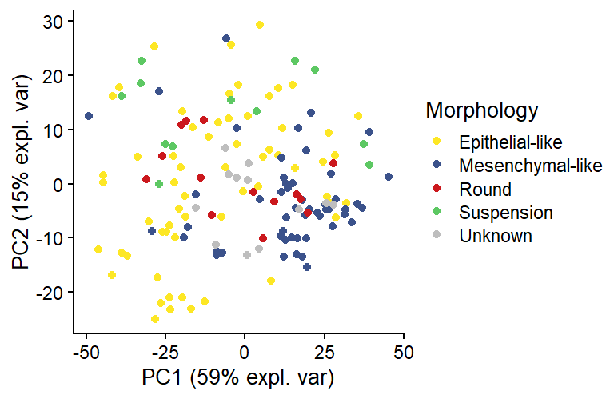

```r
fig1a <- plot_PCA_df(pca_raw_data, metadata, "Morphology") +
   scale_color_manual(values = color_legend_morphology)
fig1a
```

```r
the_legend_1a <- get_legend(
  plot_PCA_df(pca_raw_data, metadata, "Morphology") +
    guides(color = guide_legend(),
           shape = FALSE) +
    theme(legend.position = "right")
)
```

### Plot replicates

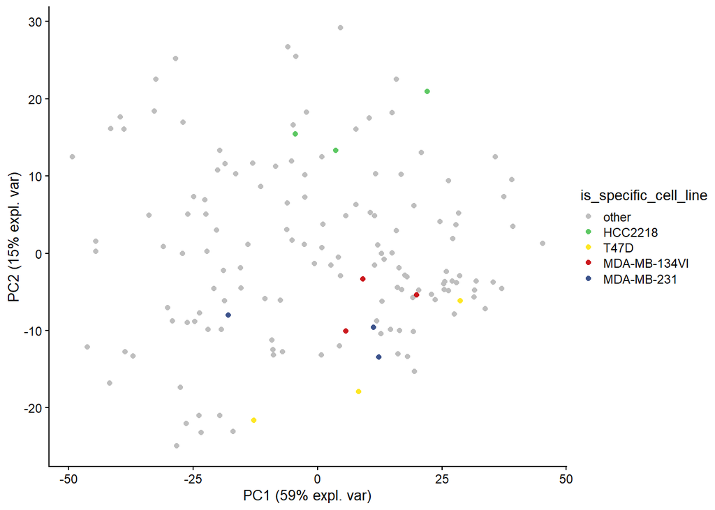

```r
metadata <- metadata %>%
  mutate(is_specific_cell_line = factor(
       ifelse(cell_line == "MDA-MB-231", "MDA-MB-231",
       ifelse(cell_line == "MDA-MB-134VI", "MDA-MB-134VI",
       ifelse(cell_line == "T47D", "T47D",
       ifelse(cell_line == "HCC2218", "HCC2218", "other")))),
       levels = c("other", "HCC2218", "T47D", "MDA-MB-134VI", "MDA-MB-231")))


fig1b <- plot_PCA_df(pca_raw_data, metadata, "is_specific_cell_line") +
  scale_color_manual(values = list(
    "MDA-MB-231" = "#3B528BFF",
    "MDA-MB-134VI" = "#CB181D",
    "T47D" = "#FDE725FF",
    "HCC2218" = "#5DC863FF",
    "other" = "grey"
  ))


fig1b
```

```r
the_legend_1b <- get_legend(
  fig1b +
    guides(color = guide_legend(),
           shape = FALSE) +
    theme(legend.position = "right")
)
```

### Color by median signal

```r
median_signal_per_sample <- dplyr::select(medians_per_sample, Original_name, log2median)
fig1c <- plot_PCA_median(pca_raw_data, median_signal_per_sample, "log2median")
```

```
## Correlation between PC1 and median signal is: -0.992408153697769
## Correlation between PC2 and median signal is: 0.0949056683089705
```

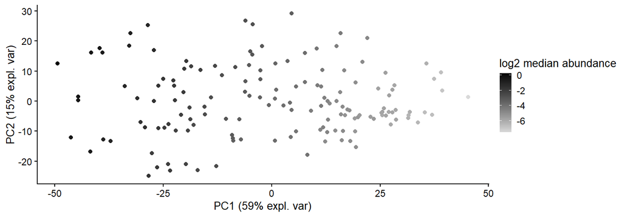

```r
fig1c
```

```r
the_legend_1def <- get_legend(
  plot_PCA_median(pca_raw_data, median_signal_per_sample, "log2median") +
    guides(color = guide_legend(),
           shape = FALSE) +
    theme(legend.position = "bottom") +
    labs(fill = "log2 median signal")
)
```

```
## Correlation between PC1 and median signal is: -0.992408153697769
## Correlation between PC2 and median signal is: 0.0949056683089705
```

Correlate PC1 to median signal

```r
plot_median_and_PC1 <- function(normalization_name){
  df <- pca_raw_data
  df <- df$variates$X %>% data.frame() %>%
    rownames_to_column("Original_name") %>%
    left_join(medians_per_sample, by = "Original_name")

  cor_nr <- round(cor(df$PC1, df$log2median, method = "spearman"), 2)
  print(str_c("Spearman correlation between PC1 and log2 median signal for ", normalization_name, " is: ",cor_nr))

  p <- df %>%
    ggplot(aes(x = log2median, y = PC1)) +
    geom_point() +
    personal_theme() +
    labs(x = "log2 median abundance", y = "PC1") +
    geom_label(x = -1.4,
              y = max(df[["PC1"]]),
              label = str_glue("r[s] == {cor_nr}"),
              label.size = NA, parse = T)
  return(p)
}

fig1d <- plot_median_and_PC1("raw data")
```

```
## [1] "Spearman correlation between PC1 and log2 median signal for raw data is: -0.99"
```

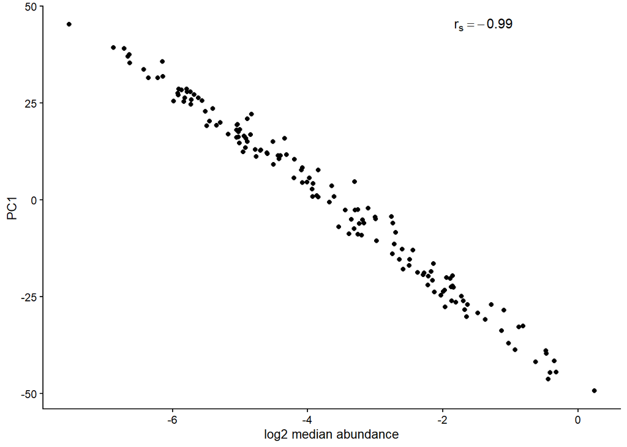

```r
fig1d
```

### Write to file

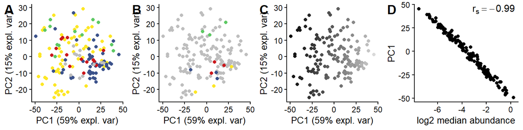

```r
all_plots_1 <- plot_grid(fig1a + theme(legend.position = "none"),
                         fig1b + theme(legend.position = "none"),
                         fig1c + theme(legend.position = "none"),
                         fig1d + theme(legend.position = "none"),
                         labels = LETTERS[1:4],
                         rel_widths = c(1,1,1,1.1),
          nrow = 1)
all_plots_1
```

```r
save_as_png_svg_pdf(
  "Figure1",
  all_plots_1,
  base_height = 2,
  base_width = 8)

save_plot(
  here(output_dir, "Figure1a_legend.png"),
  the_legend_1a)

save_plot(
  here(output_dir, "Figure1b_legend.png"),
  the_legend_1b)
```

## Figure 2

Figure 2. Data-based normalizations improved similarity between biological replicates.

### Load data

```r
# ICC calculations
ICC_cell_lines_normalization_merged <- read_csv(here(data_dir, "ICC_cell_lines_normalization_merged.csv"))
ICC_treatment_2DG_normalization_merged <- read_csv(here(data_dir, "ICC_treatment_2DG_normalization_merged.csv"))
# Three normalizations
not_normalized_Merged <- read_csv(here(data_dir, "data_normalized/cell_lines",
  "cell_lines_merged_NotNormalized_log2Transformed_notScaled.csv"))
bca_normalized_Merged <- read_csv(here(data_dir, "data_normalized/cell_lines",
  "cell_lines_merged_BCANormalized_log2Transformed_notScaled.csv"))
pqn_normalized_Merged <- read_csv(here(data_dir, "data_normalized/cell_lines",
  "cell_lines_merged_PQNNormalized_log2Transformed_notScaled.csv"))
```

### ICC of cell line panel

```r
plot_ICC <- function(all_ICCs){
  to_sort_by <- c("Not", "Prot conc.", "Cell count", "Sum", "Median", "PQN")

  p_ICC_full <- all_ICCs %>%
    pivot_longer(!lipid, names_to = "normalization", values_to = "ICC") %>%

    # Sort based on the normalization specified above
    mutate(strategy = ifelse(str_detect(normalization, "Median|Sum|PQN"), "data-based",
                               ifelse(str_detect(normalization, "Prot|Cell"), "biology-based", "not normalized")),
           normalization = factor(normalization, levels = to_sort_by)) %>%
    arrange(normalization) %>%

    # Build the plot
    ggplot(aes(x = normalization, y = ICC, fill = strategy)) +
      geom_violin() +
      geom_boxplot(position=position_dodge(1), width=0.2, fill = "white") +
      personal_theme() +
      labs(legend = "normalization type") +
      scale_x_discrete(guide = guide_axis(angle = 30)) +
      scale_y_continuous(limits = c(0, 1)) +
      scale_fill_manual(values = color_legend_icc) +
      labs(x = NULL)

  return(p_ICC_full)
}
```

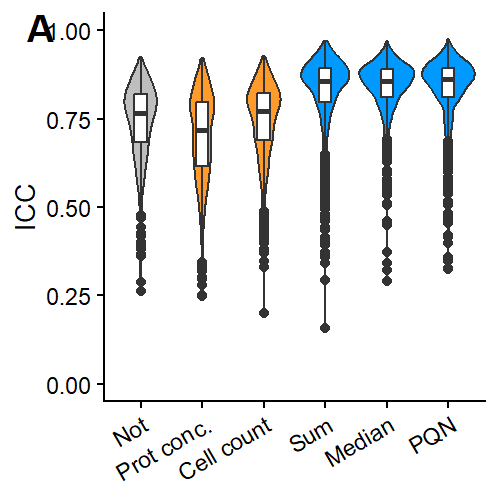

```r
fig2a <- plot_ICC(ICC_cell_lines_normalization_merged)

the_legend_2abc <- get_legend(
  fig2a +
    guides(color = guide_legend(),
           shape = FALSE) +
    theme(legend.position = "right")
)
all_plots_2a <- plot_grid(fig2a,
  align = 'vh',
  labels = LETTERS[1],
  hjust = -1,
  nrow = 1
)
all_plots_2a
```

### Density plot examples

```r
make_sample_densityplot <- function(df, to_color){
  p <- df %>%
    pivot_longer(!Original_name, names_to = "lipid") %>%
    ggplot(aes(x = value, group = Original_name)) +
    geom_density(linetype="dashed", linewidth = 0.1, color = to_color) +
    labs(x = "log2 lipid abundance") +
    personal_theme()
  return(p)
}
```

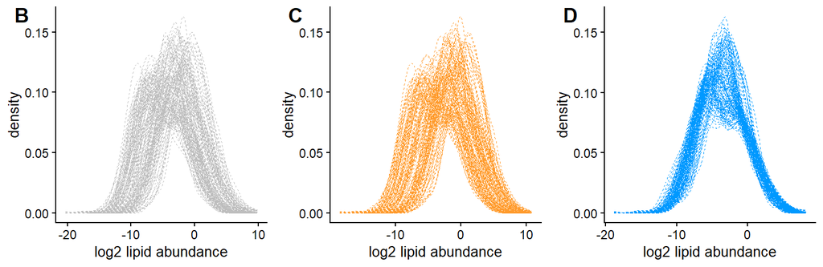

```r
fig2b <- make_sample_densityplot(not_normalized_Merged,
                                 to_color = color_legend_icc[["not normalized"]])
fig2c <- make_sample_densityplot(bca_normalized_Merged,
                                 to_color = color_legend_icc[["biology-based"]])
fig2d <- make_sample_densityplot(pqn_normalized_Merged,
                                 to_color = color_legend_icc[["data-based"]])

all_plots_2bcd <- plot_grid(fig2b, fig2c, fig2d,
  align = 'vh',
  labels = LETTERS[2:4],
  hjust = -1,
  nrow = 1
)
all_plots_2bcd
```

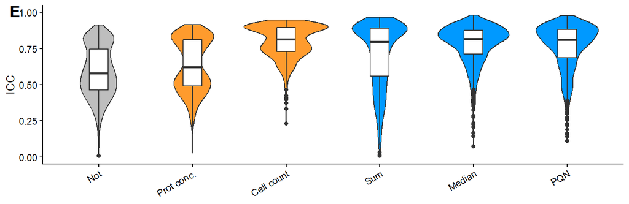

```r
fig2e <- plot_ICC(ICC_treatment_2DG_normalization_merged)

all_plots_2e <- plot_grid(fig2e,
  align = 'vh',
  labels = LETTERS[5],
  hjust = -1,
  nrow = 1
)
all_plots_2e
```

### Calculate nr of lipids with high ICC

```r
ICC_treatment_2DG_normalization_merged %>%
  column_to_rownames("lipid") %>%
  mutate(across(everything(), function(x) x > 0.7)) %>%
  colSums() %>%
  sort()
```

```
##        Not Prot conc.        Sum        PQN     Median Cell count
##        270        377        536        636        668        711
```

```r
ICC_cell_lines_normalization_merged %>%
  column_to_rownames("lipid") %>%
  mutate(across(everything(), function(x) x > 0.7)) %>%
  colSums() %>%
  sort()
```

```
## Prot conc.        Not Cell count        Sum        PQN     Median
##        473        620        622        775        792        809
```

### Write to file

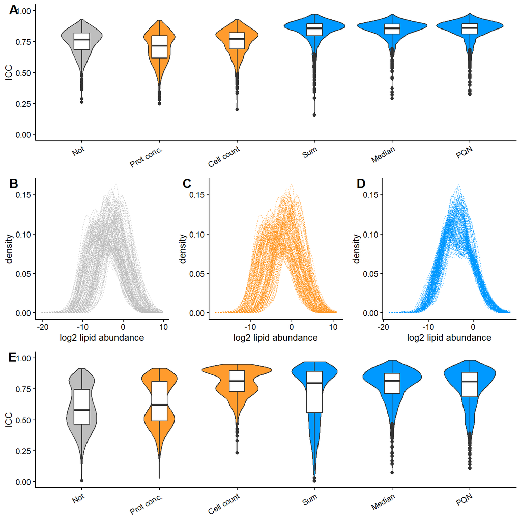

```r
plot_grid(all_plots_2a, all_plots_2bcd, all_plots_2e, ncol =1)
```

```r
save_as_png_svg_pdf(
  "Figure2",
  plot_grid(all_plots_2a, all_plots_2bcd, all_plots_2e, ncol =1),
  base_height = 8,
  base_width = 8)

save_plot(
  here(output_dir, "Figure2_legend.png"),
  the_legend_2abc)
```

## Figure 3

Figure 3. Lipid abundance distributions are not directly related to total protein concentration or cell count.

1. Distribution of lipid abundances for 5 cell lines where biological replicates have the most similar total protein concentration with a standard deviation (sd) 0.00 -0.01 µg/µL, or (B) most different total protein concentrations with a sd 0.15 - 0.30 µg/µL. Distributions for cell counts with (C) minimum 0.11 - 0.18 million cells or (D) max for 1.7 to 2.1 million cells. Distributions are colored per cell morphology with epithelial-like (yellow), mesenchymal-like (blue), round (red), or suspension (green) morphology. Correlation between the two biology-based methods (E) or between cell count (F) or protein concentration (G) and log2 median sample abundance. rs: Spearman correlation coefficient

### Load data

```r
sd_biological_measurements <- read_csv(here(data_dir, "sd_biological_measurements.csv"))
raw_data_log2 <- read_csv(here(data_dir, "raw_data_log2.csv"))
```

### Show 5 cell lines with similar and different median signals.

Plots partially based on http://www.sthda.com/english/wiki/ggplot2-violin-plot-quick-start-guide-r-software-and-data-visualization.

```r
plot_five_sample_distributions <- function(df, for_filter, max_variation = T){

  df <- df %>%
    pivot_longer(!Original_name, names_to = "lipid", values_to = "value") %>%
    left_join(metadata, by = "Original_name") %>%
    filter(group %in% for_filter$group) %>%
    left_join(for_filter, by = "group") %>%
    # sort by morphology
    mutate(Morphology = factor(Morphology, levels = names(color_legend_morphology)))
  to_sort <- df %>%
    dplyr::select(group, Morphology) %>% arrange(Morphology) %>% unique()
  df <- df %>%
    mutate(group = factor(group, levels = to_sort$group))

  p <- df %>%
    ggplot(aes(group = Original_name, x = group, y = value, fill = Morphology)) +
    geom_violin() +
    geom_boxplot(position=position_dodge(1), width=0.2, fill = "white") +
    scale_fill_manual(values = color_legend_morphology) +
    personal_theme() +
    scale_x_discrete(guide = guide_axis(angle = 20)) +
    scale_y_continuous(limits = c(-15,7)) +
    labs(x = NULL, y = "log2 lipid abundance")

  return(p)
}
```

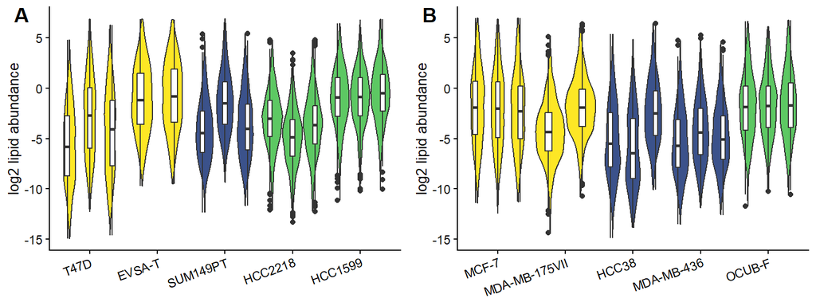

```r
max_sd <- sd_biological_measurements %>%
  slice_max(sd_protein_concentration_mg_per_mL, n = 5)

min_sd <- sd_biological_measurements %>%
  slice_min(sd_protein_concentration_mg_per_mL, n = 5)

fig3a <- raw_data_log2 %>%
  plot_five_sample_distributions(for_filter = min_sd, max_variation = F)

fig3b <- raw_data_log2 %>%
  plot_five_sample_distributions(for_filter = max_sd, max_variation = T)

the_legend_3ab <- get_legend(
  fig3a +
    guides(color = guide_legend(),
           shape = FALSE) +
    theme(legend.position = "right")
)
all_plots_3ab <- plot_grid(fig3a, fig3b,
  align = 'hv',
  labels = LETTERS[1:2],
  hjust = -1,
  nrow = 1
)
all_plots_3ab
```

Repeat for cell count

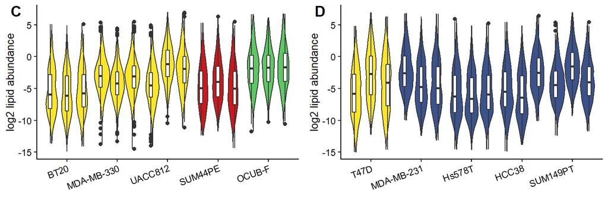

```r
max_sd <- sd_biological_measurements %>%
  slice_max(sd_cell_nr_10E6, n = 5)

min_sd <- sd_biological_measurements %>%
  slice_min(sd_cell_nr_10E6, n = 5)

fig3c <- raw_data_log2 %>%
  plot_five_sample_distributions(for_filter = min_sd, max_variation = F)

fig3d <- raw_data_log2 %>%
  plot_five_sample_distributions(for_filter = max_sd, max_variation = T)

all_plots_3cd <- plot_grid(fig3c, fig3d,
  align = 'hv',
  labels = LETTERS[3:4],
  hjust = -1,
  nrow = 1
)
all_plots_3cd
```

### Add correlation plots

Following advice on the labels on https://stackoverflow.com/questions/60189086/how-to-make-superscripts-inside-glue

```r
plot_correlation <- function(df, x, y){
  df <- df %>%
    rename_with(~str_replace_all(.x, "_", " "))
  cor_nr <- round(cor(df[[x]], df[[y]], method = "spearman"),2)
  print(cor_nr)

  p <- df %>%
    ggplot(aes(x = .data[[x]], y = .data[[y]])) +
    geom_point() +
    personal_theme() +
    geom_smooth(method = "lm", se = FALSE, color = "black", linetype = "dashed") +
    geom_label(x = 0.8*max(df[[x]]),
              y = max(df[[y]]),
              label= str_glue("r[s] == {cor_nr}"),
              label.size = NA, parse = T)
  return(p)
}

medians_per_sample <- rename(medians_per_sample,
                             "median abundance" = "median",
                             "log2 median abundance" = "log2median")

all_plots_3efg <- plot_grid(
  plot_correlation(medians_per_sample,
                   x = "cell count (million)",
                   y = "prot conc. (mg/mL)"),
  plot_correlation(medians_per_sample,
                   x = "cell count (million)",
                   y = "log2 median abundance"),
  plot_correlation(medians_per_sample,
                   x = "prot conc. (mg/mL)",
                   y = "log2 median abundance"),
  labels = LETTERS[5:7],
  rel_widths = c(1,1,1),
nrow = 1
)
```

```
## [1] 0.59
## [1] -0.19
## [1] 0.02
```

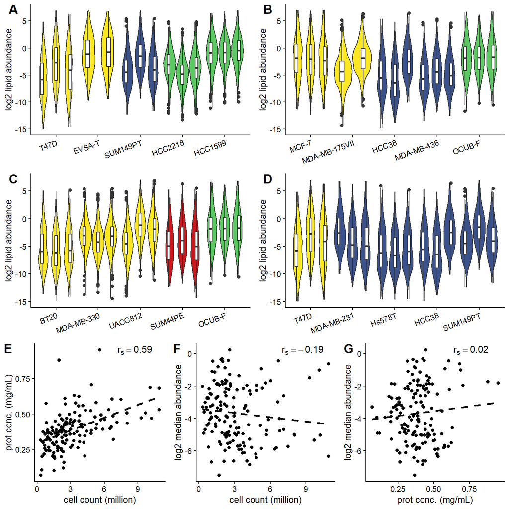

```r
all_plots_3abcdefg <-
  plot_grid(
    all_plots_3ab, all_plots_3cd, all_plots_3efg,
    nrow = 3
  )
all_plots_3abcdefg
```

### Write to file

```r
save_as_png_svg_pdf(
  "Figure3",
  all_plots_3abcdefg,
  base_height = 8,
  base_width = 8)

save_plot(
  here(output_dir, "Figure3_legend.png"),
  the_legend_3ab)
```

## Figure 4

Figure 4 Correlation between class averages before normalization shows an overall agreement for structural lipids, but not for triglycerides and some signaling lipids.

Lipid abundances are log2 transformed, scaled, and centered. Class averages are calculated for cell line biological replicates before normalization, and Pearson correlation is used to correlate class averages over all samples. Rows and columns are clustered using hierarchical clustering with Euclidean distances and complete linkage.

Following instructions on https://slowkow.com/notes/pheatmap-tutorial/ and https://biocorecrg.github.io/CRG_RIntroduction/pheatmap-function-from-the-pheatmap-package.html

```r
class_average_correlations <- read_csv(here(data_dir, "class_average_correlations.csv")) %>%
  rename("unknown" = "unknown.sphingolipid") %>%
  rename("PG/BMP" = "PG_or_BMP") %>%
  mutate(lipid_subclass = str_replace(lipid_subclass, "unknown.sphingolipid", "unknown")) %>%
  mutate(lipid_subclass = str_replace(lipid_subclass, "PG_or_BMP", "PG/BMP")) %>%
  column_to_rownames("lipid_subclass")
min(class_average_correlations)
```

```
## [1] 0.2172752
```

```r
max(class_average_correlations)
```

```
## [1] 1
```

```r
# Sort dendogram to emphasize similarity
library(dendsort)
```

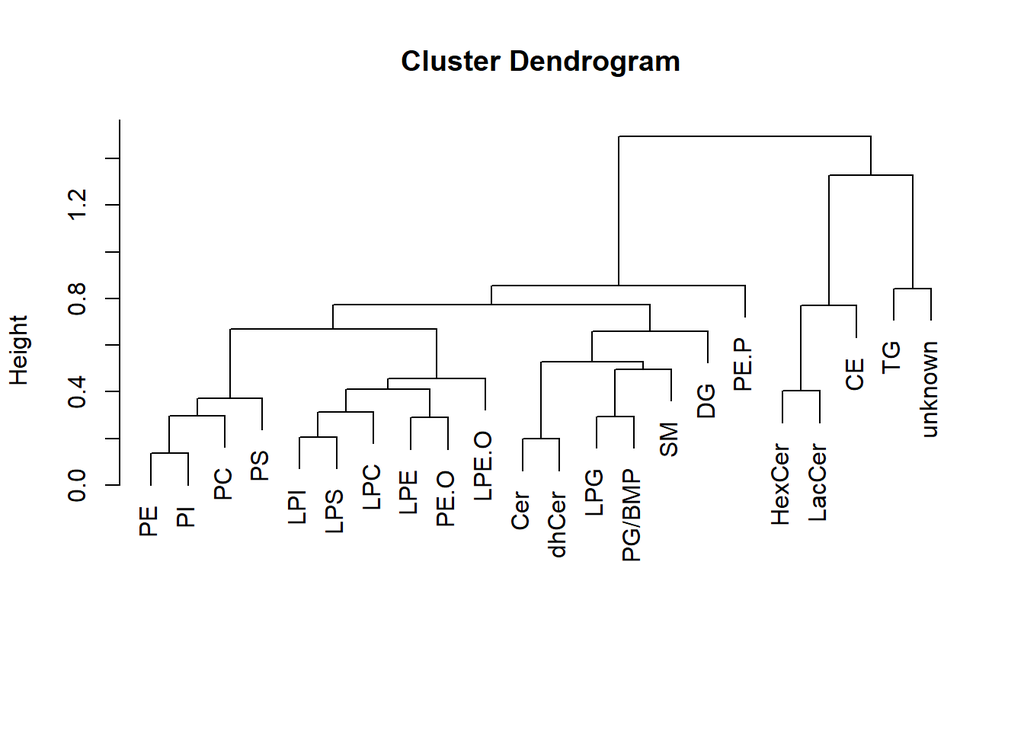

```r
sort_hclust <- function(...) as.hclust(dendsort(as.dendrogram(...)))
cluster_cols <- sort_hclust(hclust(dist(class_average_correlations)))
plot(cluster_cols, xlab = "", sub = "")
```

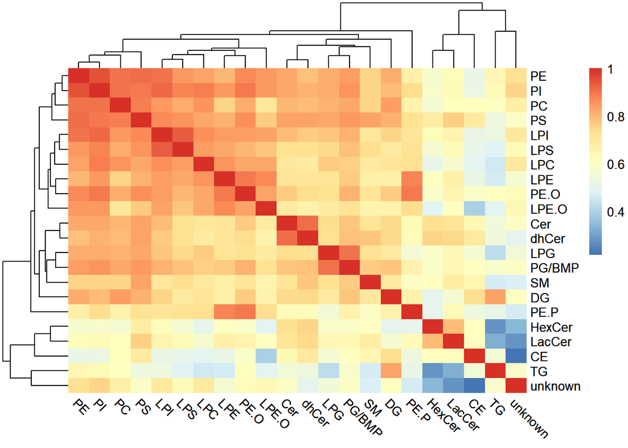

```r
fig4a <- pheatmap(class_average_correlations,
         cluster_rows = cluster_cols,
         cluster_cols = cluster_cols,
         border_color = NA,
         angle_col = "315")
fig4a
```

Include correlation of raw data not transformed sums of all structural lipids.

```r
plot_correlation_sums <- function(df, x, y){
  df <- df %>%
    rename_with(~str_replace_all(.x, "_", " "))
  cor_nr <- round(cor(df[[x]], df[[y]], method = "spearman"),2)
  print(cor_nr)

  p <- df %>%
    ggplot(aes(x = .data[[x]], y = .data[[y]])) +
    geom_point() +
    personal_theme() +
    #geom_smooth(method = "lm", se = FALSE, color = "black", linetype = "dashed") +
    geom_label(x = 0.6*max(df[[x]]),
              y = 0.95*max(df[[y]]),
              label= str_glue("r[s] == {cor_nr}"),
              label.size = NA, parse = T)
  return(p)
}
```

```r
sums_of_SL_and_TGs <- read_csv(here(data_dir, "rawdata_sums_of_structural_lipids_and_TGs.csv")) %>%
  left_join(metadata, by = "Original_name") %>%
  rename("cell count (million)" = cell_nr_10E6)
head(sums_of_SL_and_TGs)
```

| Original_name | structural_lipid_sum | TG_sum | group | cell_line | Treatment | Time | biological_replicate | batch_MSMS | Study | cell count (million) | corrected_conc_mg_per_mL | Morphology | Cellosaurus_RRID | Cellosaurus_Cell_line_name | is_specific_cell_line |
| --- | --- | --- | --- | --- | --- | --- | --- | --- | --- | --- | --- | --- | --- | --- | --- |
| 101_SUM190PT | 532.1685 | 37.20241 | SUM190PT | SUM190PT | NA | NA | 2 | 3 | Cell_line_panel | 1.710 | 0.3419157 | Epithelial-like | CVCL_3423 | SUM190PT | other |
| 103_SK-BR-5 | 732.6205 | 38.13784 | SK-BR-5 | SK-BR-5 | NA | NA | 2 | 2 | Cell_line_panel | 1.160 | 0.2404598 | Unknown | CVCL_5217 | SK-BR-5 | other |
| 104_OCUB-F | 1747.3528 | 419.53137 | OCUB-F | OCUB-F | NA | NA | 2 | 3 | Cell_line_panel | 2.230 | 0.3333333 | Suspension | CVCL_3352 | OCUB-F | other |
| 105_HCC2218 | 507.3482 | 74.54465 | HCC2218 | HCC2218 | NA | NA | 2 | 3 | Cell_line_panel | 0.523 | 0.3734866 | Suspension | CVCL_1263 | HCC2218 | HCC2218 |
| 106_DU4475 | 166.2406 | 2.68145 | DU4475 | DU4475 | NA | NA | 2 | 3 | Cell_line_panel | 4.020 | 0.4240613 | Suspension | CVCL_1183 | DU4475 | other |
| 107_HCC1187 | 1142.3068 | 472.20944 | HCC1187 | HCC1187 | NA | NA | 2 | 3 | Cell_line_panel | 2.590 | 0.3481992 | Mesenchymal-like | CVCL_1247 | HCC1187 | other |

```r
fig4b <- sums_of_SL_and_TGs %>%
  plot_correlation_sums(x = "cell count (million)", y = "structural lipid sum")
```

```
## [1] 0.08
```

```r
fig4c <- sums_of_SL_and_TGs %>%
  plot_correlation_sums(x = "cell count (million)", y = "TG sum")
```

```
## [1] -0.33
```

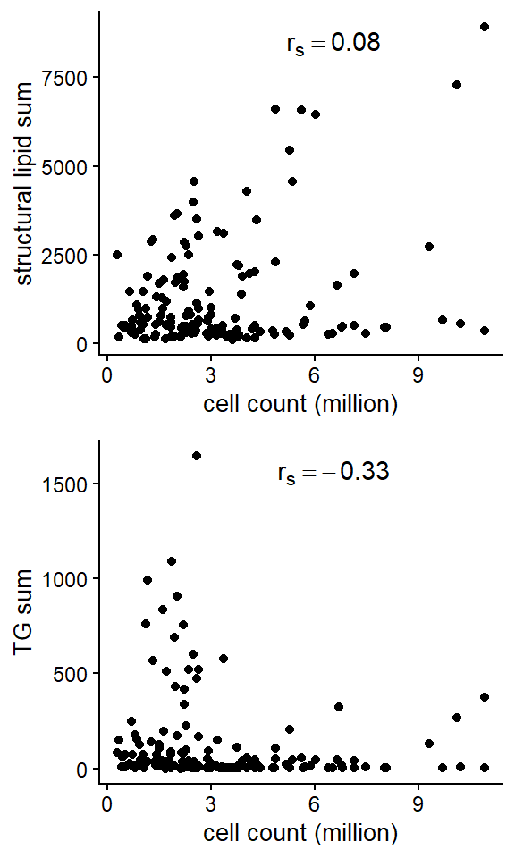

```r
plot_grid(fig4b, fig4c,ncol = 1)
```

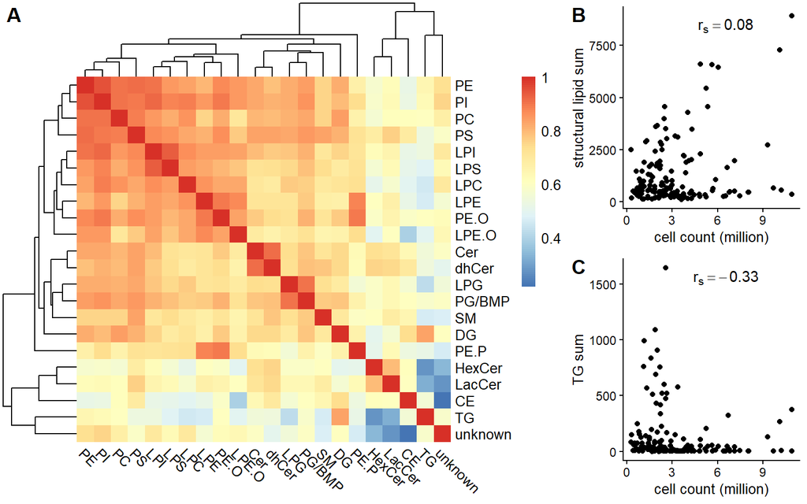

```r
all_plots_4 <- plot_grid(fig4a$gtable,
          plot_grid(fig4b, fig4c,
                   ncol= 1, labels=LETTERS[2:3]),
          nrow = 1,
          labels = c(LETTERS[1],""),
          rel_widths = c(0.7,0.3)
)
all_plots_4
```

### Write to file

```r
save_as_png_svg_pdf("Figure4", all_plots_4,
                    base_height = 5, base_width = 8)
```

## Figure 5

Figure 5 Differences in PE class average between morphologies are partially caused by normalization.

### Load data

```r
class_averages_by_structural_lipids <- read_csv(here(data_dir, "class_averages_by_structural_lipids.csv"))
class_averages_merged <- read_csv(here(data_dir, "class_averages_merged.csv"))
class_averages_rawdata <- read_csv(here(data_dir, "class_averages_TGPE_rawdata.csv"))
```

### Violin plots

```r
violin_plot_lipid_class_average <- function(df){
  p <- metadata %>%
    dplyr::select(Original_name, Morphology) %>%
    unique() %>%
    right_join(df, by = "Original_name") %>%
    filter(Morphology %in% c("Epithelial-like", "Mesenchymal-like")) %>%
    mutate(Morphology = substr(Morphology, 1,1)) %>%
  ggplot(aes(x = Morphology, y = class_mean, fill = Morphology)) +
    geom_violin() +
    geom_boxplot(position=position_dodge(1), width=0.2, fill = "white") +
    scale_fill_manual(values = color_legend_morphology) +
    personal_theme() +
    labs(x = NULL, y = "class average")
  return(p)
}
```

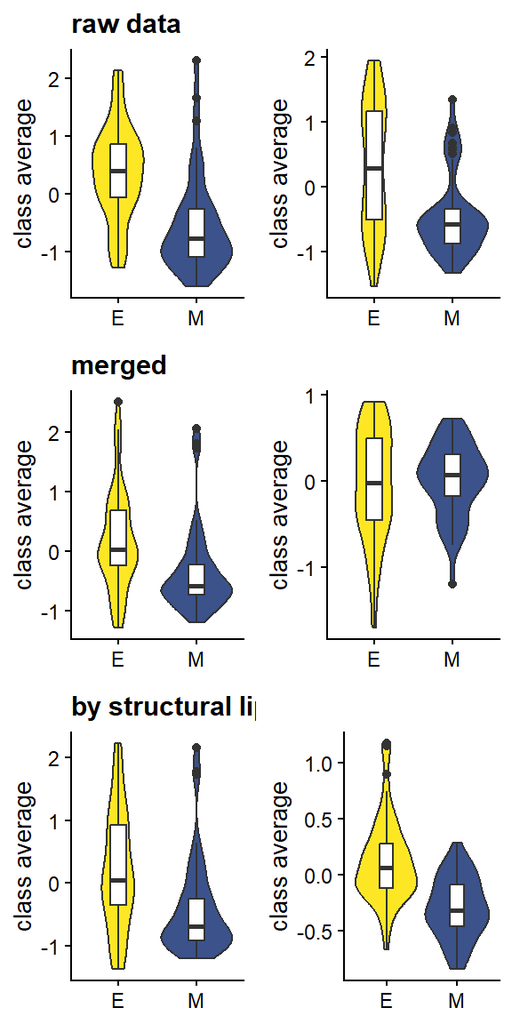

```r
TG_rawdata <- class_averages_rawdata %>% filter(class == "TG") %>%
  violin_plot_lipid_class_average()
PE_rawdata <- class_averages_rawdata %>% filter(class == "PE") %>%
  violin_plot_lipid_class_average()

TG_merged <- class_averages_merged %>% filter(class == "TG") %>%
  violin_plot_lipid_class_average()
PE_merged <- class_averages_merged %>% filter(class == "PE") %>%
  violin_plot_lipid_class_average()

TG_by_structural_lipids <- class_averages_by_structural_lipids %>% filter(class == "TG") %>%
  violin_plot_lipid_class_average()
PE_by_structural_lipids <- class_averages_by_structural_lipids %>% filter(class == "PE") %>%
  violin_plot_lipid_class_average()

plot_grid(
  plot_grid(TG_rawdata + ggtitle("raw data"), PE_rawdata, align = "h"),
  plot_grid(TG_merged + ggtitle("merged"), PE_merged, align = "h"),
  plot_grid(TG_by_structural_lipids + ggtitle("by structural lipids"), PE_by_structural_lipids, align = "h"),
  nrow = 3
)
```

### Correlation plots

```r
# correlation between the class averages after normalization
extract_TG_PE <- function(df){
  df <- df %>%
    filter(class %in% c("TG", "PE")) %>%
    dplyr::select(Original_name, class, class_mean) %>%
    pivot_wider(id_cols = Original_name, names_from = class, values_from = class_mean)
  return(df)
}
calculate_TG_PE_cor <- function(df){
  cor_nr <- round(cor(df$PE, df$TG), 2)
  return(cor_nr)
}

correlation_plot_TGPE <- function(class_averages, show_cor = F){
  cor_nr <- calculate_TG_PE_cor(class_averages)
  print(cor_nr)
  p <- class_averages %>%
    ggplot(aes(x = PE, y = TG)) +
      geom_point() +
      personal_theme() +
      geom_smooth(method = "lm", se = FALSE, color = "black", linetype = "dashed")
  if(show_cor){
    p <- p +
      geom_label(x = max(class_averages$PE),
                y = max(class_averages$TG),
                hjust = 1,
                label= str_glue("r = {cor_nr}"),
                label.size = NA)
  }
  return(p)
}
```

```r
# correlation between the class averages after structural lipid-based normalization

class_averages <- extract_TG_PE(class_averages_by_structural_lipids)
PE_TG_correlation_by_structural_lipids <- correlation_plot_TGPE(class_averages, show_cor = T)
```

```
## [1] 0.31
```

```r
# correlation between the class averages after merged normalization

class_averages <- extract_TG_PE(class_averages_merged)
PE_TG_correlation_merged <- correlation_plot_TGPE(class_averages, show_cor = T)
```

```
## [1] -0.76
```

```r
# correlation between the class averages before normalization
class_averages <- extract_TG_PE(class_averages_rawdata)
PE_TG_correlation_rawdata <- correlation_plot_TGPE(class_averages, show_cor = T)
```

```
## [1] 0.65
```

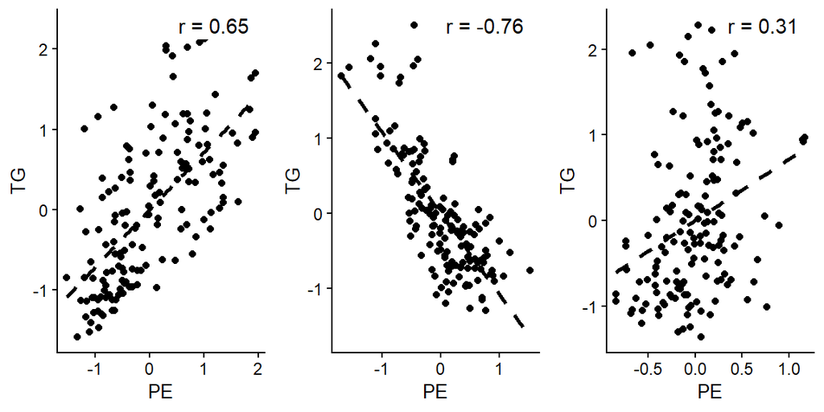

```r
plot_grid(PE_TG_correlation_rawdata, PE_TG_correlation_merged, PE_TG_correlation_by_structural_lipids, nrow = 1)
```

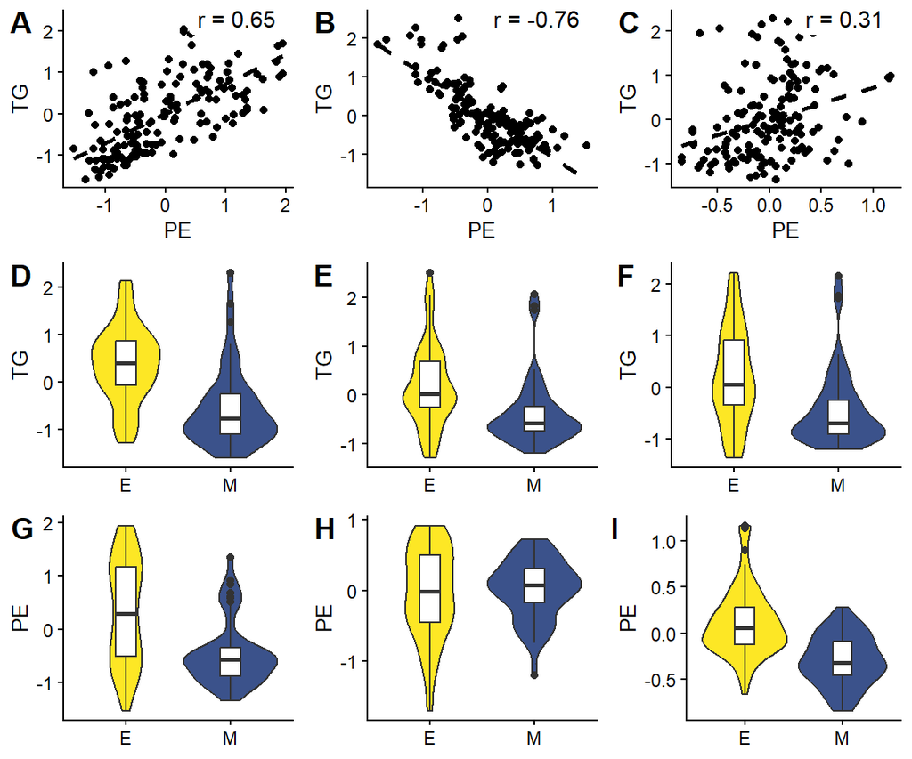

```r
all_plots_5 <- plot_grid(
  plot_grid(PE_TG_correlation_rawdata,
            PE_TG_correlation_merged,
            PE_TG_correlation_by_structural_lipids,
            labels = LETTERS[1:3], nrow = 1),
  plot_grid(TG_rawdata + labs(y = "TG"),
            TG_merged + labs(y = "TG"),
            TG_by_structural_lipids + labs(y = "TG"),
            labels = LETTERS[4:6], nrow = 1),
  plot_grid(PE_rawdata + labs(y = "PE"),
            PE_merged + labs(y = "PE"),
            PE_by_structural_lipids + labs(y = "PE"),
            labels = LETTERS[7:9], nrow = 1),
  align = 'v',
  hjust = -0.5,
  nrow = 3
)
all_plots_5
```

### Write to file

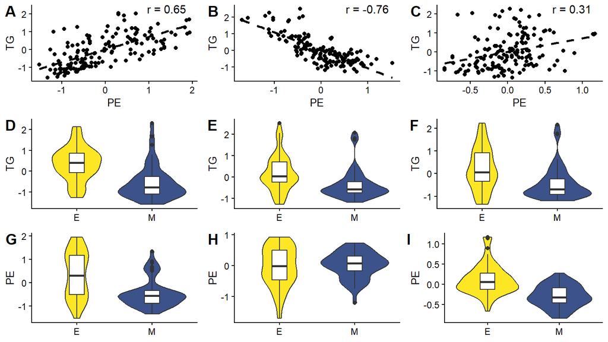

```r
all_plots_5
```

```r
save_as_png_svg_pdf(
  "Figure5",
  all_plots_5,
  base_height = 4,
  base_width = 8)
```

## Figure 6

Figure 6 Correlation of PCs after data transformation shows similar results.

### Load data

```r
pqn_data_log2 <- read_csv(here(data_dir, "pqn_data_log2.csv")) %>% column_to_rownames("group")
pqn_data_cuberoot <- read_csv(here(data_dir, "pqn_data_cuberoot.csv")) %>% column_to_rownames("group")
```

### Plot PCA loadings

```r
make_comparison_plot <- function(PCA_comparison, x, y, multiplyPC){
  p <- PCA_comparison %>%
    left_join(lipid_info, by = c("lipid" = "internal_identifiers")) %>%
    ggplot(aes(x = .data[[x]], y = .data[[y]], color = class)) +
    geom_point() +
    personal_theme() +
    scale_color_viridis_d(option = "H") +
    labs(x = str_replace_all(x, "_", " "),
         y = str_replace_all(y, "_", " ")) +
    geom_abline(slope = 1*multiplyPC, color = "black", linetype = "dashed")
  return(p)
}

plot_loadings <- function(pca_log2, pca_cuberoot, show_positivePC1 = T, show_positivePC2 = T,
                          plot_PC3 = F, show_positivePC3 = T){
  # Set by hand whether I want to flip a PC axis
  multiplyPC1 <- ifelse(show_positivePC1, 1, -1)
  multiplyPC2 <- ifelse(show_positivePC2, 1, -1)

  # Plot correlation between loading values
  PCA_comparison <- full_join(
    data.frame(pca_log2$loadings$X) %>% rownames_to_column("lipid"),
    data.frame(pca_cuberoot$loadings$X) %>% rownames_to_column("lipid"),
    by = "lipid",
    suffix = c("_log2", "_cuberoot")
  )

  # Compare correlation between first principal components for both modes
  p_pca1 <- make_comparison_plot(PCA_comparison, x = "PC1_log2", y = "PC1_cuberoot", multiplyPC1)

  # Compare correlation between second principal components for both modes
  p_pca2 <- make_comparison_plot(PCA_comparison, x = "PC2_log2", y = "PC2_cuberoot", multiplyPC2)

  if(plot_PC3){
    multiplyPC3 <- ifelse(show_positivePC3, 1, -1)
    # Compare correlation between second principal components for both modes
    p_pca3 <- make_comparison_plot(PCA_comparison, x = "PC3_log2", y = "PC3_cuberoot", multiplyPC3)
    return(list(p_pca1, p_pca2, p_pca3))
  }else{
    return(list(p_pca1, p_pca2))
  }
}
```

```r
pca_log2 <- mixOmics::pca(pqn_data_log2, scale = F, ncomp = 3)
pca_cuberoot <- mixOmics::pca(pqn_data_cuberoot, scale = F, ncomp = 3)
print(str_c("Overlapping nr of max lipids in PC1 is ",
  intersect(
    pca_log2$loadings$X %>% data.frame() %>% arrange(desc(abs(PC1))) %>% rownames() %>% head(10),
    pca_cuberoot$loadings$X %>% data.frame() %>% arrange(desc(abs(PC1))) %>% rownames() %>% head(10)) %>%
  length()))
```

```
## [1] "Overlapping nr of max lipids in PC1 is 9"
```

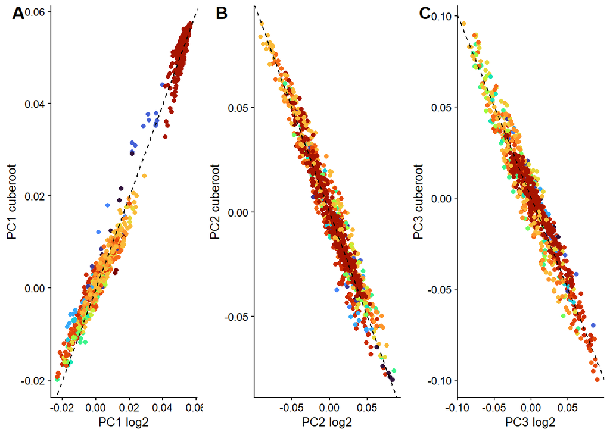

```r
pca_plots <- plot_loadings(pca_log2, pca_cuberoot, show_positivePC1 = T, show_positivePC2 = F,
                           plot_PC3 = T, show_positivePC3 = F)

all_plots <- plot_grid(
  pca_plots[[1]] + theme(legend.position = "none"),
  pca_plots[[2]] + theme(legend.position = "none"),
  pca_plots[[3]] + theme(legend.position = "none"),
  align = 'vh',
  labels = LETTERS[1:3],
  hjust = -1,
  nrow = 1
)

all_plots
```

### Venn diagram after differential analysis

#### Load data

```r
load(here(data_dir, "venn_diagram_differential_lipids.RData"))
```

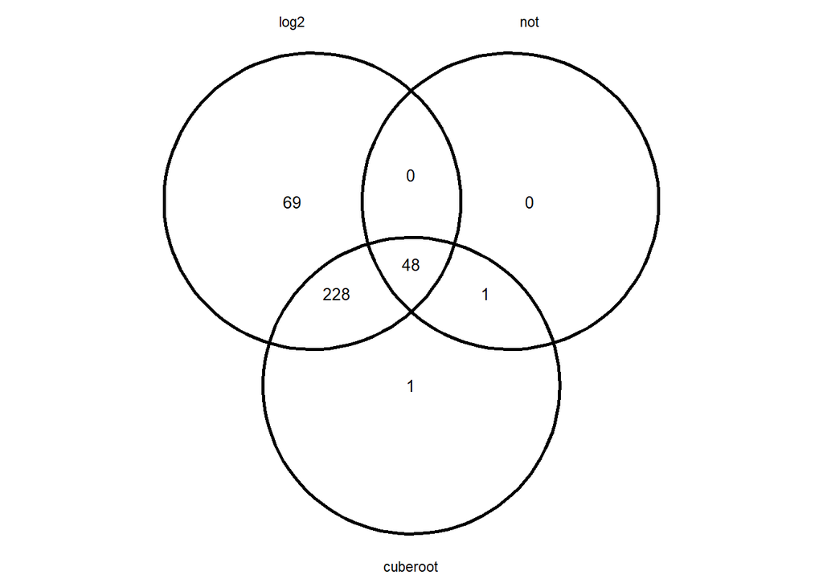

```r
venn_diagram <- ggvenn(venn_diagram_differential_lipids,
       show_percentage = F, fill_alpha = 0,
       set_name_size = 3, text_size = 3.5) +
  theme(plot.background = element_rect(fill = NA, color = NA))
venn_diagram
```

### Combine plots

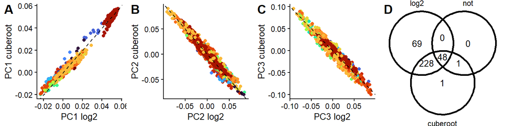

```r
all_plots_6 <- plot_grid(
  pca_plots[[1]] + theme(legend.position = "none"),
  pca_plots[[2]] + theme(legend.position = "none"),
  pca_plots[[3]] + theme(legend.position = "none"),
  venn_diagram,
  labels = LETTERS[1:4],
  rel_heights = c(1,1,1,0.5),
  #hjust = -1,
  nrow = 1
)

all_plots_6
```

### Write to file

```r
save_as_png_svg_pdf(
  "Figure6",
  all_plots_6,
  base_height = 2,
  base_width = 8)
```

# Supplementary figures

## Supplementary Figure 1

```r
sums_of_SL_and_TGs <-  sums_of_SL_and_TGs %>%
  rename("prot conc. (mg/mL)" = corrected_conc_mg_per_mL)
head(sums_of_SL_and_TGs)
```

| Original_name | structural_lipid_sum | TG_sum | group | cell_line | Treatment | Time | biological_replicate | batch_MSMS | Study | cell count (million) | prot conc. (mg/mL) | Morphology | Cellosaurus_RRID | Cellosaurus_Cell_line_name | is_specific_cell_line |
| --- | --- | --- | --- | --- | --- | --- | --- | --- | --- | --- | --- | --- | --- | --- | --- |
| 101_SUM190PT | 532.1685 | 37.20241 | SUM190PT | SUM190PT | NA | NA | 2 | 3 | Cell_line_panel | 1.710 | 0.3419157 | Epithelial-like | CVCL_3423 | SUM190PT | other |
| 103_SK-BR-5 | 732.6205 | 38.13784 | SK-BR-5 | SK-BR-5 | NA | NA | 2 | 2 | Cell_line_panel | 1.160 | 0.2404598 | Unknown | CVCL_5217 | SK-BR-5 | other |
| 104_OCUB-F | 1747.3528 | 419.53137 | OCUB-F | OCUB-F | NA | NA | 2 | 3 | Cell_line_panel | 2.230 | 0.3333333 | Suspension | CVCL_3352 | OCUB-F | other |
| 105_HCC2218 | 507.3482 | 74.54465 | HCC2218 | HCC2218 | NA | NA | 2 | 3 | Cell_line_panel | 0.523 | 0.3734866 | Suspension | CVCL_1263 | HCC2218 | HCC2218 |
| 106_DU4475 | 166.2406 | 2.68145 | DU4475 | DU4475 | NA | NA | 2 | 3 | Cell_line_panel | 4.020 | 0.4240613 | Suspension | CVCL_1183 | DU4475 | other |
| 107_HCC1187 | 1142.3068 | 472.20944 | HCC1187 | HCC1187 | NA | NA | 2 | 3 | Cell_line_panel | 2.590 | 0.3481992 | Mesenchymal-like | CVCL_1247 | HCC1187 | other |

```r
sup1a <- sums_of_SL_and_TGs %>%
  plot_correlation_sums(x = "prot conc. (mg/mL)", y = "structural lipid sum")
```

```
## [1] 0.22
```

```r
sup1b <- sums_of_SL_and_TGs %>%
  plot_correlation_sums(x = "prot conc. (mg/mL)", y = "TG sum")
```

```
## [1] -0.09
```

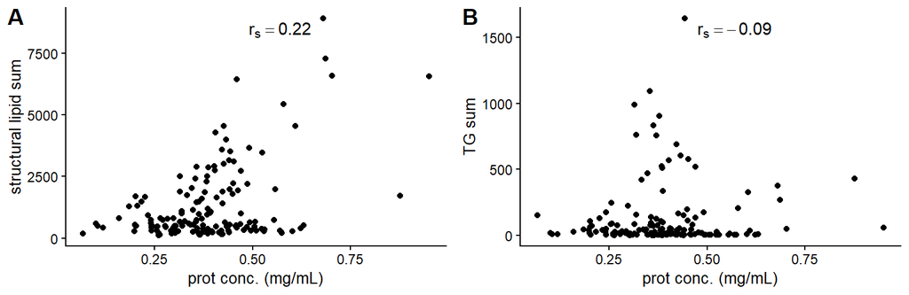

```r
plot_grid(sup1a, sup1b,
            align = 'vh',
            labels = LETTERS[1:2],
            nrow = 1)
```

```r
save_as_png_svg_pdf(
  "SupplementaryFigure1",
  plot_grid(sup1a, sup1b,
            align = 'vh',
            labels = LETTERS[1:2],
            nrow = 1),
  base_height = 2.6,
  base_width = 8
  )
```

## Supplementary Figure 2

ICCs after log2 or cube root transformation

```r
ICC_cell_lines_transformation <- read_csv(here(data_dir, "ICC_cell_lines_transformation.csv"))
```

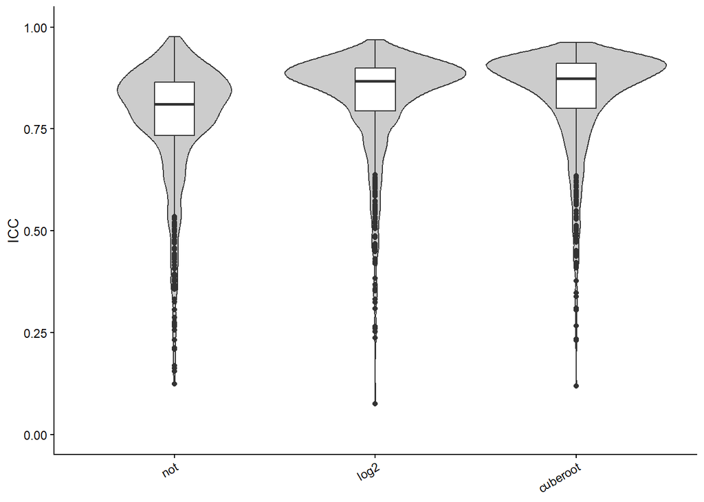

```r
plot_ICC <- function(all_ICCs){
  to_sort_by <- c("not", "log2", "cuberoot")

  p_ICC_full <- all_ICCs %>%
    pivot_longer(!lipid, names_to = "transformation", values_to = "ICC") %>%
    # Sort based on the order specified above
    mutate(transformation = factor(transformation, levels = to_sort_by)) %>%
    arrange(transformation) %>%

    # Build the plot
    ggplot(aes(x = transformation, y = ICC)) +
      geom_violin(fill = "grey80") +
      geom_boxplot(position=position_dodge(1), width=0.2, fill = "white") +
      personal_theme() +
      scale_x_discrete(guide = guide_axis(angle = 30)) +
      scale_y_continuous(limits = c(0, 1)) +
      labs(x = NULL)

  return(p_ICC_full)
}
plot_ICC(ICC_cell_lines_transformation)
```

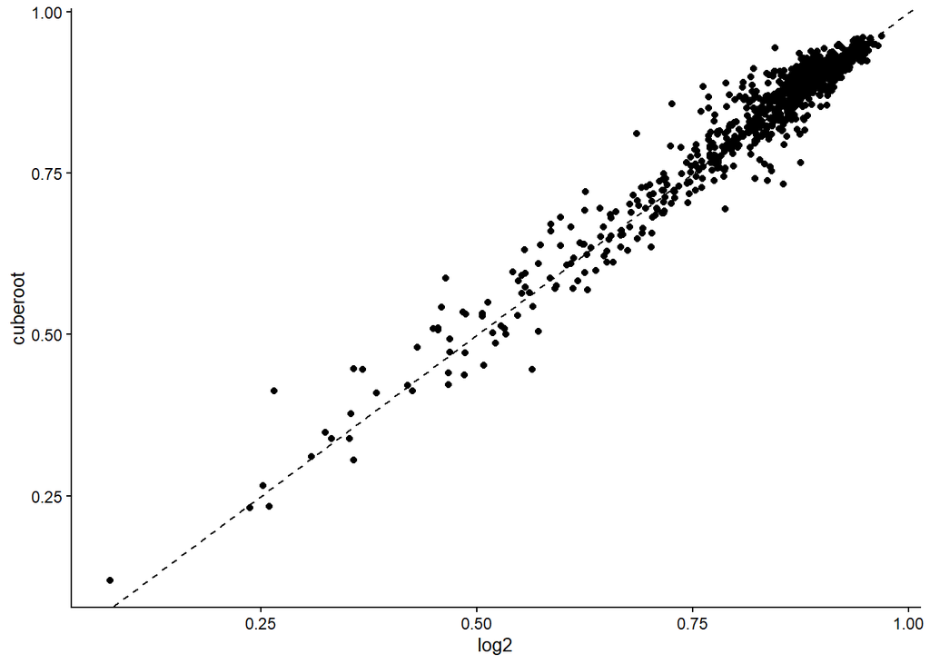

```r
plot_correlation_log2_cuberoot <- ICC_cell_lines_transformation %>%
  ggplot(aes(x = log2, y = cuberoot)) +
    geom_point() +
    personal_theme() +
    geom_abline(slope = 1, intercept = 0, color = "black", linetype = "dashed")
plot_correlation_log2_cuberoot
```

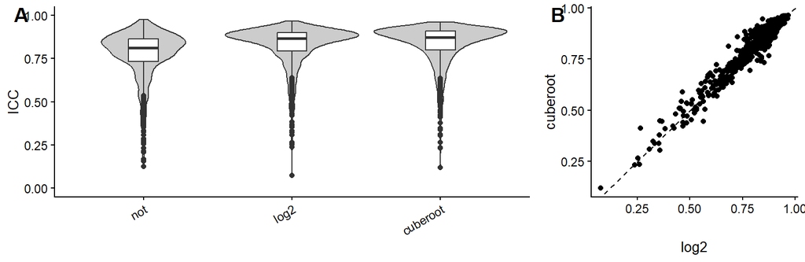

```r
all_plots_sup2 <- plot_grid(
  plot_ICC(ICC_cell_lines_transformation),
  plot_correlation_log2_cuberoot,
  align = 'vh',
  labels = c("A", "B"),
  hjust = -1,
  nrow = 1,
  rel_widths = c(2,1)
)
all_plots_sup2
```

### Write to file

```r
save_as_png_svg_pdf(
  "SupplementaryFigure2",
  all_plots_sup2,
  base_height = 2.6,
  base_width = 8
)
```

## Supplementary Figure 3

```r
BT549_density_info <- read_csv(here(data_dir, "BT549_density_info.csv")) %>%
  rename(replicate = biological_replicate)
```

```r
plot_BT549_density_info <- function(df,y_label = F){
  df <- mutate(df, normalization = as.factor(str_replace(normalization, "Normalized", " normalized"))) %>%
    mutate(replicate = factor(replicate))
  p1 <- df %>%
    filter(transformation == "log2Transformed") %>%
  ggplot(aes(x = value, color = replicate)) + geom_density() +
    facet_grid(~ normalization, scales = "free") +
    personal_theme() +
    theme(strip.background =element_rect(fill="white")) +
    labs(x = NULL, y = NULL)

  p2 <- df %>%
    filter(transformation != "log2Transformed") %>%
  ggplot(aes(x = value, color = replicate)) + geom_density() +
    facet_grid(~ normalization, scales = "free") +
    personal_theme() +
    theme(strip.text = element_blank()) +
    labs(x = NULL, y = NULL)
  if(y_label){
    p1 <- p1 + labs(x = NULL, y = "log2 transformed")
    p2 <- p2 + labs(x = NULL, y = "cube root transformed")
  }
  return(plot_grid(p1, p2, nrow = 2, align = "vh"))
}
p_sup3 <- BT549_density_info %>%
  plot_BT549_density_info(y_label = T)
```

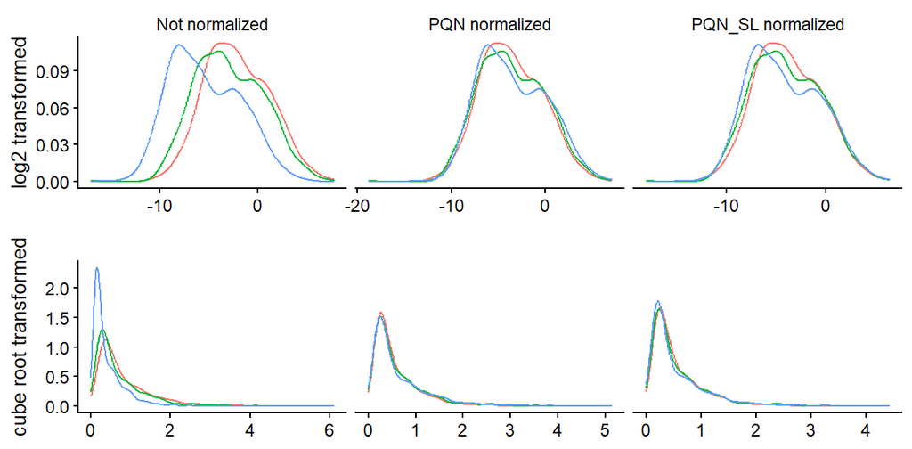

```r
all_plots_sup3 <- plot_grid(
  p_sup3,
  align = 'vh',
  hjust = -1,
  nrow = 1
)

all_plots_sup3
```

### Write to file

```r
save_as_png_svg_pdf(
  "SupplementaryFigure3",
  all_plots_sup3 + theme(plot.background = element_rect(fill = "white", color = "white")),
  base_height = 3.15,
  base_width = 6.4)
```